# Chapter 3: Multiple Regression with Categorical Regressors

Statistical Modelling Methods: A Guide for the Social and Behavioural Sciences (2nd ed.)

Author

David Flora & Miranda Too

# Chapter 3 Textbook Content

## Loading R Packages

```r
library(misty)
```

## Research Example

This artificial data provided by Darlington and Hayes (2017) examines the association between marital status and general life satisfaction.

## Importing data

```r
married <- read.csv("married.txt", sep="")
str(married)
```

```
'data.frame':   36 obs. of  4 variables:
 $ mstatus: int  3 2 4 4 1 3 2 2 3 1 ...
 $ satis  : int  85 80 72 60 92 88 74 84 88 82 ...
 $ age    : int  53 63 55 39 65 74 57 59 58 51 ...
 $ gender : int  0 1 0 0 1 1 0 0 0 0 ...
```

The marriage variable `mstatus` is coded into four categories: 1 = married, 2 = divorced, 3 = single, and 4 = widowed. Life satisfaction, `satis`, is a continuous variable with possible scores ranging from 0 to 100.

```r
#Replacing numerical codes with category labels
married$mstatus <- factor(married$mstatus, labels=c('married','divorced','single','widowed'))
str(married$mstatus)
```

```
 Factor w/ 4 levels "married","divorced",..: 3 2 4 4 1 3 2 2 3 1 ...
```

### Table 3.1: Descriptive statistics of life satisfaction by marital status

```r
#Life satisfaction descriptive statistics by marital status group

descript(married$satis, group = married$mstatus, print = c("n","m",'sd','med','skew','kurt'))
```

```
 Descriptive Statistics

  Group      n     M   SD   Med  Skew  Kurt
   married  10 83.80 6.23 83.00  0.17 -1.30
   divorced  9 81.44 4.82 84.00 -0.97 -0.71
   single    9 78.89 6.25 76.00  0.64 -1.32
   widowed   8 77.38 8.57 79.00 -0.93  0.22
```

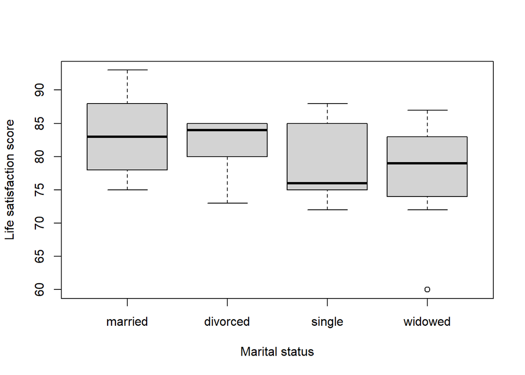

```r
boxplot(married$satis~married$mstatus, ylab='Life satisfaction score', xlab='Marital status')
```

## Dummy-Variable Regression and ANOVA

First, we can create dummy variables in accordance with Table 3.2:

```r
#This code creates dummy variables d1, d2, and d3, and puts them in the 'married' data frame.

married$d1 <- ifelse(married$mstatus=="divorced", 1, 0)
#If mstatus is divorced, then d1 = 1, else d1 = 0

married$d2 <- ifelse(married$mstatus=="single", 1, 0)
#If mstatus is divorced, then d2 = 1, else d2 = 0

married$d3 <- ifelse(married$mstatus=="widowed", 1, 0)
#If mstatus is widowed, then d3 = 1, else d3 = 0
```

Then, we can use the dummy variables to represent the nominal marital status variable and fit the model represented in Equation 3.1 to obtain the results in Table 3.3:

```r
#Life Satisfaction regressed on marital status
dummyMod <- lm(satis ~ d1+d2+d3, data=married)
summary(dummyMod)
```

```
Call:
lm(formula = satis ~ d1 + d2 + d3, data = married)

Residuals:
     Min       1Q   Median       3Q      Max
-17.3750  -3.8889   0.3778   3.7167   9.6250

Coefficients:
            Estimate Std. Error t value Pr(>|t|)
(Intercept)   83.800      2.064  40.610   <2e-16 ***
d1            -2.356      2.998  -0.786    0.438
d2            -4.911      2.998  -1.638    0.111
d3            -6.425      3.095  -2.076    0.046 *
---
Signif. codes:  0 '***' 0.001 '**' 0.01 '*' 0.05 '.' 0.1 ' ' 1

Residual standard error: 6.525 on 32 degrees of freedom
Multiple R-squared:  0.1381,    Adjusted R-squared:  0.05728
F-statistic: 1.709 on 3 and 32 DF,  p-value: 0.1849
```

```r
#Notice that the results match the values reported in Table 3.3.

#Get confidence intervals too
confint(dummyMod)
```

```
                 2.5 %     97.5 %
(Intercept)  79.596764 88.0032363
d1           -8.462716  3.7516052
d2          -11.018272  1.1960497
d3          -12.729854 -0.1201455
```

Instead of literally creating dummy variables and then using them in the regression model, we can simply refer to the original, factor-type, multi-category variable (`mstatus`) in the model formula, and the ‘lm()’ function will automatically (by default) treat the factor-variable as a set of dummy variables to fit the model, as shown next:

```r
#You can use the `levels()` function to check the levels of a variable and find out what the reference category is:
levels(married$mstatus)
```

```
[1] "married"  "divorced" "single"   "widowed"
```

```r
#The first listed category ("married") will be the reference category.

#Life Satisfaction regressed on marital status
anovaMod <- lm(satis ~ mstatus, data=married)
summary(anovaMod)
```

```
Call:
lm(formula = satis ~ mstatus, data = married)

Residuals:
     Min       1Q   Median       3Q      Max
-17.3750  -3.8889   0.3778   3.7167   9.6250

Coefficients:
                Estimate Std. Error t value Pr(>|t|)
(Intercept)       83.800      2.064  40.610   <2e-16 ***
mstatusdivorced   -2.356      2.998  -0.786    0.438
mstatussingle     -4.911      2.998  -1.638    0.111
mstatuswidowed    -6.425      3.095  -2.076    0.046 *
---
Signif. codes:  0 '***' 0.001 '**' 0.01 '*' 0.05 '.' 0.1 ' ' 1

Residual standard error: 6.525 on 32 degrees of freedom
Multiple R-squared:  0.1381,    Adjusted R-squared:  0.05728
F-statistic: 1.709 on 3 and 32 DF,  p-value: 0.1849
```

```r
#Obtain confidence intervals around model parameters
confint(anovaMod)
```

```
                     2.5 %     97.5 %
(Intercept)      79.596764 88.0032363
mstatusdivorced  -8.462716  3.7516052
mstatussingle   -11.018272  1.1960497
mstatuswidowed  -12.729854 -0.1201455
```

```r
#Notice that the estimates and confidence intervals are exactly the same as when the model was fitted to the dummy variables!
#Again, each estimate pertains to the comparison of one category with the reference category.
#For example, output for "mstatusdivorced" pertains to a comparison of the divorced category with the married (reference) category.
```

## The ANCOVA Model and Beyond

### Table 3.4

To investigate whether satisfaction scores significantly differ across marital status groups while holding age constant, we can use a hierarchical regression strategy: (1) fit a model with satisfaction regressed on age, then (2) fit a model with satisfaction regressed on age and marital status, and then (3) use an F-test to determine whether R-squared significantly increased.

```r
# (1) Fit model with satisfaction regressed on age
mod0 <- lm(satis ~ age, data=married)
summary(mod0)
```

```
Call:
lm(formula = satis ~ age, data = married)

Residuals:
    Min      1Q  Median      3Q     Max
-11.826  -3.417   0.432   4.213   9.656

Coefficients:
            Estimate Std. Error t value Pr(>|t|)
(Intercept)  50.4350     7.4046   6.811 7.77e-08 ***
age           0.5485     0.1338   4.100 0.000243 ***
---
Signif. codes:  0 '***' 0.001 '**' 0.01 '*' 0.05 '.' 0.1 ' ' 1

Residual standard error: 5.578 on 34 degrees of freedom
Multiple R-squared:  0.3309,    Adjusted R-squared:  0.3112
F-statistic: 16.81 on 1 and 34 DF,  p-value: 0.0002427
```

```r
#From this output, we mainly just want to note that R^2 = .3309


# (2) Fit a model with satisfaction regressed on martial status and age
ancovaMod <- lm(satis ~ mstatus+age, data=married)
summary(ancovaMod)
```

```
Call:
lm(formula = satis ~ mstatus + age, data = married)

Residuals:
     Min       1Q   Median       3Q      Max
-10.8493  -3.2661  -0.0666   3.4583  10.4251

Coefficients:
                Estimate Std. Error t value Pr(>|t|)
(Intercept)      52.6171     8.4649   6.216 6.65e-07 ***
mstatusdivorced  -3.8510     2.5547  -1.507 0.141831
mstatussingle    -1.8525     2.6512  -0.699 0.489928
mstatuswidowed   -4.7357     2.6437  -1.791 0.083013 .
age               0.5539     0.1472   3.764 0.000701 ***
---
Signif. codes:  0 '***' 0.001 '**' 0.01 '*' 0.05 '.' 0.1 ' ' 1

Residual standard error: 5.493 on 31 degrees of freedom
Multiple R-squared:  0.4084,    Adjusted R-squared:  0.3321
F-statistic: 5.351 on 4 and 31 DF,  p-value: 0.002144
```

```r
#Recall that since "married" was the reference category, each of the estimates for the marital status categories refers to a comparison with those who are married (holding age constant in the `ancovaMod` model.
#But at this point, the output of interest is R^2 = .4084


# (3) Compare the models with an F-test using the anova function
anova(mod0, ancovaMod)
```

```
Analysis of Variance Table

Model 1: satis ~ age
Model 2: satis ~ mstatus + age
  Res.Df    RSS Df Sum of Sq      F Pr(>F)
1     34 1057.8
2     31  935.2  3    122.62 1.3549 0.2748
```

```r
#This F-test tells us that the R^2 increase from .3309 to .4084 is not significant, p = .2748.
```

### Comparing adjusted means across groups

```r
library(emmeans)
emmeans(ancovaMod, ~mstatus)
```

```
 mstatus  emmean   SE df lower.CL upper.CL
 married    83.0 1.75 31     79.5     86.6
 divorced   79.2 1.93 31     75.3     83.1
 single     81.2 1.93 31     77.2     85.1
 widowed    78.3 1.96 31     74.3     82.3

Confidence level used: 0.95
```

```r
#The values listed under the "emmean" column correspond to the adjusted means reported in the text.
```

## Regression Diagnostics with Categorical Regressors

### Figure 3.2: Scatterplot of Studentized Residuals by Age

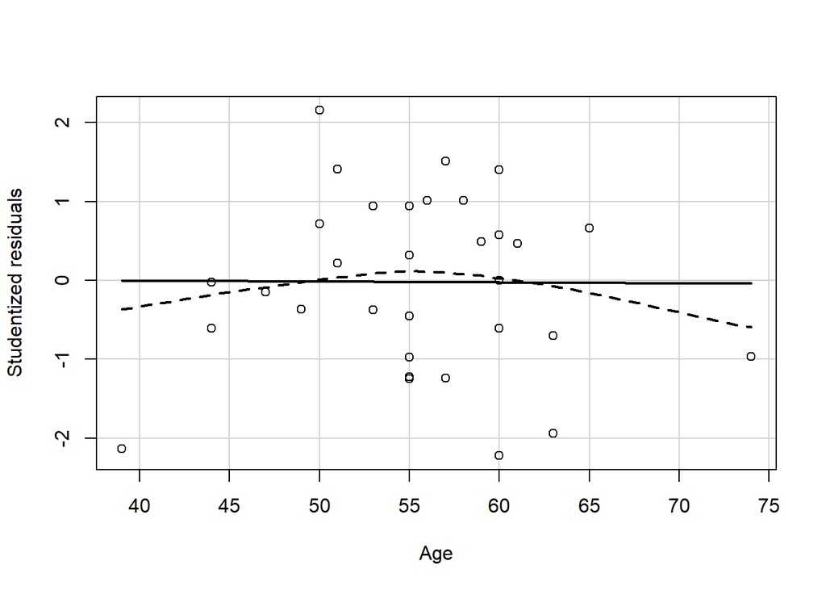

```r
library(car)
scatterplot(rstudent(ancovaMod)~married$age, ylab='Studentized residuals',
            xlab='Age', boxplot=F, col="black", smooth=list(var=F, span=1.0))
```

### Figure 3.3: Boxplot of Studentized Residuals by Marital Status

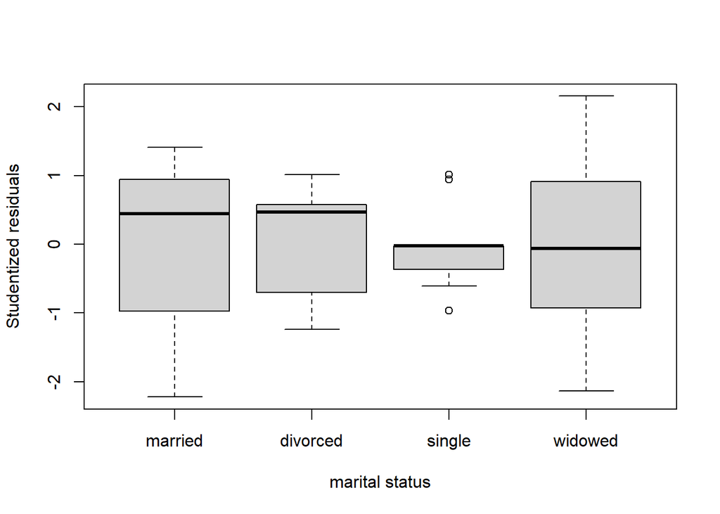

```r
boxplot(rstudent(ancovaMod)~married$mstatus, ylab='Studentized residuals', xlab='marital status')
```

### Figure 3.4: Q-Q Plot of Model

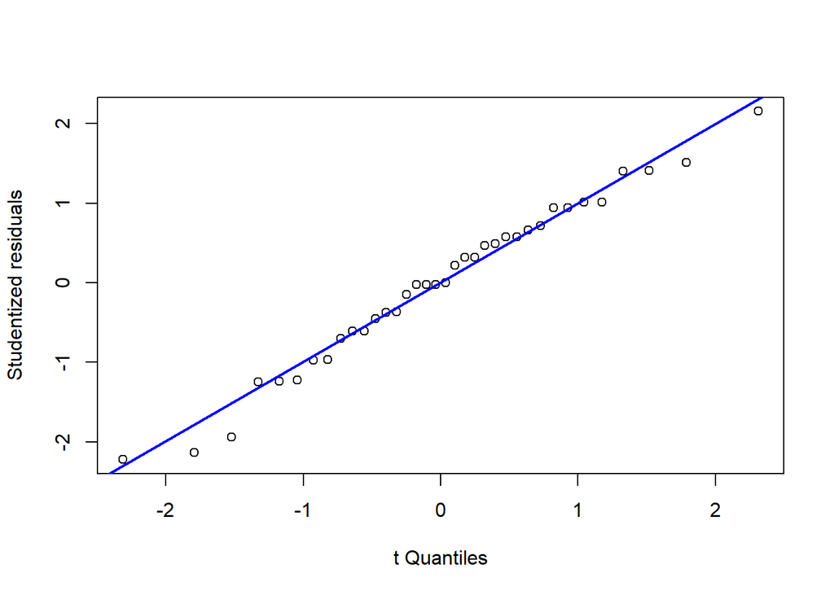

```r
qqPlot(ancovaMod, envelope = F, ylab = "Studentized residuals", grid=F, id=F)
```

## Using Contrast-Code Variables

The following material accompanies the supplementary text for this chapter.

### Creating Helmert contrasts

As described above, by default R will represent a factor-type variable using a set of dummy variables. We can use the `contrasts()` function to see that the `mstatus` variable is currently represented as a set of three dummy variables with “married” as the reference category:

```r
contrasts(married$mstatus)
```

```
         divorced single widowed
married         0      0       0
divorced        1      0       0
single          0      1       0
widowed         0      0       1
```

```r
#Notice how this table corresponds to the table of dummy variable values in Table 3.2 of the text.
```

But we can specify an alternative set of contrasts using the `matrix()` function. Here, we create a matrix called `helmerts` which contains the contrast-code values given in Table S3.1 in the supplementary text. Because we need to create three contrasts, the matrix has three columns (`ncol=3`). Then, we assign this new `helmerts` matrix to the contrasts representing `mstatus`, thereby overriding the dummy variables:

```r
helmerts <- matrix(c(-1/3,-1/3,  1,-1/3,
                        1,-1/2,  0,-1/2,
                        0,   1,  0,-1),
                      ncol=3)
contrasts(married$mstatus) <- helmerts

#check what the contrasts look like now:
contrasts(married$mstatus)
```

```
               [,1] [,2] [,3]
married  -0.3333333  1.0    0
divorced -0.3333333 -0.5    1
single    1.0000000  0.0    0
widowed  -0.3333333 -0.5   -1
```

```r
#The first column corresponds to the "C1" variable in the supplementary text (single vs. others)
#The 2nd column corresponds to the "C2" variable (married vs. divorced and widowed)
#The 3rd column corresponds to the "C3" variable (divorced vs. widowed)
```

Now, when we regress the `satis` outcome on `mstatus`, we get results based on these contrasts instead of dummy variables:

```r
mod.helm <- lm(satis ~ mstatus, data=married)
summary(mod.helm)
```

```
Call:
lm(formula = satis ~ mstatus, data = married)

Residuals:
     Min       1Q   Median       3Q      Max
-17.3750  -3.8889   0.3778   3.7167   9.6250

Coefficients:
            Estimate Std. Error t value Pr(>|t|)
(Intercept)   80.377      1.091  73.676   <2e-16 ***
mstatus1      -1.488      1.886  -0.789    0.436
mstatus2       2.927      1.735   1.687    0.101
mstatus3       2.035      1.585   1.283    0.209
---
Signif. codes:  0 '***' 0.001 '**' 0.01 '*' 0.05 '.' 0.1 ' ' 1

Residual standard error: 6.525 on 32 degrees of freedom
Multiple R-squared:  0.1381,    Adjusted R-squared:  0.05728
F-statistic: 1.709 on 3 and 32 DF,  p-value: 0.1849
```

```r
confint(mod.helm)
```

```
                2.5 %    97.5 %
(Intercept) 78.154871 82.599295
mstatus1    -5.329201  2.352813
mstatus2    -0.606843  6.460547
mstatus3    -1.194605  5.264049
```

```r
#Notice how the results match those in supplementary Table S3.2
```

### Improved contrasts

Next, we can change the contrasts to match the ‘improved contrasts’ represented in Table S3.3:

```r
helmert2 <- matrix(c(-1/4,-1/4,3/4,-1/4,
                      2/3,-1/3,  0,-1/3,
                      0,    .5,  0,-.5),
                      ncol=3)
contrasts(married$mstatus) <- helmert2

#check what the contrasts look like now:
contrasts(married$mstatus)
```

```
          [,1]       [,2] [,3]
married  -0.25  0.6666667  0.0
divorced -0.25 -0.3333333  0.5
single    0.75  0.0000000  0.0
widowed  -0.25 -0.3333333 -0.5
```

And then fit the model again:

```r
mod.helm <- lm(satis ~ mstatus, data=married)
summary(mod.helm)
```

```
Call:
lm(formula = satis ~ mstatus, data = married)

Residuals:
     Min       1Q   Median       3Q      Max
-17.3750  -3.8889   0.3778   3.7167   9.6250

Coefficients:
            Estimate Std. Error t value Pr(>|t|)
(Intercept)   80.377      1.091  73.676   <2e-16 ***
mstatus1      -1.984      2.514  -0.789    0.436
mstatus2       4.390      2.602   1.687    0.101
mstatus3       4.069      3.171   1.283    0.209
---
Signif. codes:  0 '***' 0.001 '**' 0.01 '*' 0.05 '.' 0.1 ' ' 1

Residual standard error: 6.525 on 32 degrees of freedom
Multiple R-squared:  0.1381,    Adjusted R-squared:  0.05728
F-statistic: 1.709 on 3 and 32 DF,  p-value: 0.1849
```

```r
confint(mod.helm)
```

```
                 2.5 %    97.5 %
(Intercept) 78.1548713 82.599295
mstatus1    -7.1056020  3.137083
mstatus2    -0.9102645  9.690820
mstatus3    -2.3892096 10.528098
```

```r
#Now the results match those in supplementary Table S3.4
```